# Perturbation of transverse motion

The Hamiltonian of an unperturbed motion is

\begin{align} H=\frac{p_x^2}{2}+\frac{p_y^2}{2}+\left(\frac{1}{2\rho^2}+\frac{k(s)}{2} \right) x^2-\frac{k(s)}{2}y^2 \end{align}

Now we assume that the motion is perturbed by $\Delta \mathbf{B}(s) = \Delta B_x(s) \hat{x}+\Delta B_y(s) \hat{y}$, where

\begin{align} \Delta B_y+i\Delta B_x &= B_0 \sum_{n=0}^\infty \left(\Delta b_n + i \Delta a_n\right) \left(x+iy\right)^{n} \end{align}

The vector potential becomes:

\begin{align} \Delta A_s=-B_0 \Re \sum_{n=0}^\infty \frac {b_n + i a_n}{n+1} \left(x+iy\right)^{n+1} \end{align}

The Hamiltonian becomes:

\begin{align} H=\frac{p_x^2}{2}+\frac{p_y^2}{2}+\left(\frac{1}{2\rho^2}+\frac{k(s)}{2} \right) x^2-\frac{k(s)}{2}y^2 \pm \frac{1}{B\rho} \Delta A_s \end{align}

Here, the plus and minus sign reflect the negative and positive charge particle respectively.

Then the Hill's equation becomes:

\begin{align} x''+\left(\frac{1}{\rho^2}+k(s)\right)x&= -\frac{\Delta B_y}{B\rho} \\ y''-k(s)y&=\frac{\Delta B_x}{B\rho} \end{align}

If $\Delta B_y$ is not a function of $y$, and $\Delta B_x$ is not a function of $x$, these two equation remain decoupled. The linear effect of uncoupled case will be introduce in the next two sub-sections. The linear coupled case will be introduced in the last sub-section.

## Perturbed orbit

The perturbed orbit rises from the dipole errors, which can be contributed from a dipole strength error or a quadrupole misalignment.

### Green function of Hill's equation

At the present of the dipole error, the general Hill's equation becomes:

\begin{equation} x''\left(s\right)+\kappa\left(s\right)x\left(s\right)=-\frac{\Delta B_y(s)}{B_0\rho} \end{equation}

The solution can be retrieved from the Green's function method. The green function is the solution of:

\begin{equation} x''\left(s\right)+\kappa\left(s\right)x\left(s\right)=\theta\delta\left(s-s_0\right) \end{equation}

This shows that a delta function dipole changes the orbit by $\theta$ at location $s_0$

Integrate the function at the vicinity of the $s_0$ gives:

\begin{equation} x'\left(s_{0+}\right)-x'\left(s_{0-}\right)=\theta \label{eq:angle_kick} \end{equation}

#### Linac accelerator

From the linear accelerator, the beam only pass $s_0$ once. From the transfer matrix from $s_0$ to $s_1$

\begin{equation} M\left(s_{1}\mid s_{0}\right) =\left(\begin{array}{cc} \sqrt{{\frac{\beta_{1}}{\beta_{0}}}}\left(\cos\psi+\alpha_{0}\sin\psi\right) & \sqrt{\beta_{0}\beta_{1}}\sin\psi\\ -\frac{1+\alpha_{0}\alpha_{1}}{\sqrt{\beta_{0}\beta_{1}}}\sin\psi+\frac{\alpha_{0}-\alpha_{1}}{\sqrt{\beta_{0}\beta_{1}}}\cos\psi & \sqrt{{\frac{\beta_{0}}{\beta_{1}}}}\left(\cos\psi-\alpha_{1}\sin\psi\right) \end{array}\right) \label{eq:tmatrix_s0s1} \end{equation}

where $\psi(s)=\psi(s_1)-\psi(s_0)$. We get the response of the delta dipole error, or the Green's function (normalized by $\theta$) as:

\begin{equation} G(s, s_0)=\frac{x(s)}{\theta}=\sqrt{\beta_{s}\beta_{s_0}}\sin\left(\psi\left(s\right)-\psi\left(s_0\right)\right) H\left(s-s_0\right) \end{equation}

Here, $H(x)$ is the Heaviside step function.

Then for an arbitrary dipole error distribution $\frac{\Delta B(s)}{B_0\rho}$, the centroid orbit becomes:

\begin{align} x(s) &=\int_{-\infty}^{\infty}\frac{\Delta B(s_0)}{B_0\rho}G(s,s_0)ds_0 \nonumber\\ &=\sqrt{\beta(s)}\int_{-\infty}^{s}\frac{\sqrt{\beta(s_0)}\Delta B(s_0)}{B_0\rho}\sin\left(\psi\left(s\right)-\psi\left(s_0\right)\right) ds_0 \end{align}

#### Ring accelerator

In ring accelerator, the beam will pass $s_0$ many times. There exist a stable orbit, deviate from the reference orbit, due to the dipole error. This is called closed orbit.

In every turn, the beam will have a kick at $s_0$ described in $\ref{eq:angle_kick}$. Combined with the one-turn matrix $M(s_0)$,

\begin{equation} M\left(s_{0}\right)= \left(\begin{array}{cc} \cos\Phi+\alpha_{0}\sin\Phi & \beta_{0}\sin\Phi\\ -\frac{1+\alpha_{0}^{2}}{\beta_{0}}\sin\Phi & \cos\Phi-\alpha_{0}\sin\Phi \end{array}\right) \end{equation}

Here $\Phi=2\pi\nu$. we have a closed orbit condition:

\begin{equation} \left(\begin{array}{c} x\\ x'_{-}=x'_{+}-\theta \end{array}\right)= \left(\begin{array}{cc} \cos\Phi+\alpha_{0}\sin\Phi & \beta_{0}\sin\Phi\\ -\frac{1+\alpha_{0}^{2}}{\beta_{0}}\sin\Phi & \cos\Phi-\alpha_{0}\sin\Phi \end{array}\right) \left(\begin{array}{c} x\\ x'_{+} \end{array}\right) \end{equation}

Solve the equation, we have:

\begin{equation} \left(I-M\right) \left(\begin{array}{c} x\\ x'_{+} \end{array}\right) = \left(\begin{array}{c} 0\\ \theta \end{array}\right) \end{equation}

From the $\det(I-M)=2-2\cos\Phi$ the stable value of $x$ can be easily found as:

\begin{align} x(s_0)&=\frac{\beta\left(s_0\right)\sin\Phi}{2-2\cos\Phi}\theta=\frac{\beta\left(s_0\right)\cos\pi\nu}{2\sin\pi\nu}\theta \\ x'(s_{0+})&=\frac{1-\cos\Phi-\alpha\sin\Phi}{2-2\cos\Phi}\theta=\frac{\sin\pi\nu-\alpha\left(s_0\right)\cos\pi\nu}{2\sin\pi\nu}\theta \end{align}

Here, the betatron tune is $\nu$. Then using the transfer matrix $\ref{eq:tmatrix_s0s1}$, we get the Green's function:

\begin{align} G\left(s,s_{0}\right) & =\frac{x(s)}{\theta}\nonumber\\ & =\frac{\sqrt{\beta\left(s\right)\beta\left(s_{0}\right)}}{{2\sin\pi\nu}}\left(\cos\pi\nu\left(\cos\psi+\alpha\left(s_{0}\right)\sin\psi\right)+\sin\psi\left(\sin\pi\nu-\alpha\left(s_{0}\right)\cos\pi\nu\right)\right)\nonumber\\ & =\frac{\sqrt{\beta\left(s\right)\beta\left(s_{0}\right)}}{{2\sin\pi\nu}}\cos\left(\psi\left(s\right)-\psi\left(s_{0}\right)-\pi\nu\right) \end{align}

Therefore, for an arbitrary dipole error distribution $\frac{\Delta B(s)}{B_0\rho}$, the closed orbit is simply:

\begin{align} x_{co}(s)&=\int_{s}^{s+C}\frac{\Delta B(s_0)}{B_0\rho}G\left(s,s_{0}\right) ds_0 \\ &=\frac{\sqrt{\beta\left(s\right)}}{2\sin\pi\nu}\int_{s}^{s+C}\sqrt{\beta\left(s_0\right)}\frac{\Delta B(s_0)}{B_0\rho} \cos\left(\psi\left(s\right)-\psi\left(s_{0}\right)-\pi\nu\right) ds_0 \end{align}

Let's define the 'rotating angle' to $\phi(s)=\psi(s)/\nu$, then

\begin{align} d\phi=\frac{1}{\nu}\frac{d\psi}{ds}ds=\frac{1}{\nu \beta}ds \end{align}

Therefore:

\begin{align} x_{co}(s)&=\frac{\nu\sqrt{\beta\left(s\right)}}{2\sin(\pi\nu)}\int_{\phi(s)}^{\phi(s)+2\pi}\sqrt{\beta\left(\phi\right)^3}\frac{\Delta B(\phi)}{B_0\rho} \cos\nu\left(\phi\left(s\right)-\phi-\pi\right) d\phi \end{align}

The advantage of writing the integral using the 'rotating angle' is to perform Fourier analysis easily. We can expand:

\begin{align} \beta^{3/2}(\phi)\frac{\Delta B(\phi)}{B_0\rho}=\sum_{m=-\infty}^{\infty}f_m e^{im\phi} \end{align}

Then the closed orbit is written as:

\begin{align} x_{co}&=\sqrt{\beta\left(s\right)}\sum_{m=-\infty}^{\infty} \frac{\nu^2 f_m}{\nu^2-m^2} e^{im\phi(s)} \end{align}

[figure not shown]

```
[[ 1.12825172  1.98092285]
 [-0.99046143 -0.85267114]]
```

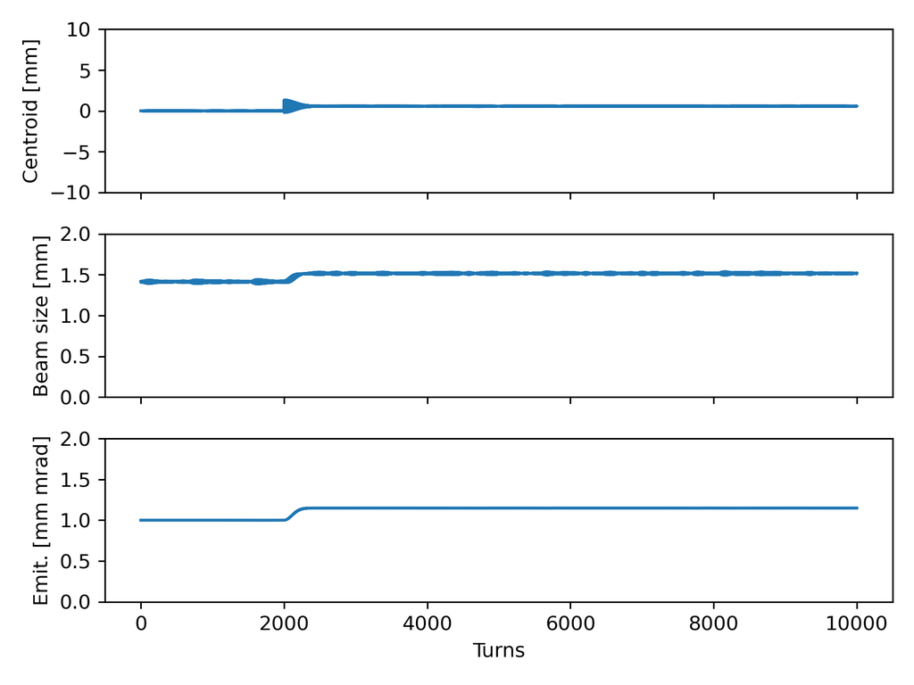

```python
from map2D import map2D
import numpy as np
import matplotlib.pyplot as plt
#from matplotlib import animation
#from IPython.display import HTML
%matplotlib notebook

dipole_error=map2D(npart=10000, twiss=[2,1], twiss_beam=[2,1],tune=0.228, chrom=10, espr=1e-4)
avex,avep,sizex,sizep,emit=dipole_error.statistics()
emitlist=[]
sizelist=[]
avelist=[]
N_turn=10000

print(dipole_error.linmap)

def evolve_func(turns, kick_turn_start=2000, kick_angle=5e-4,
               ):
    for i in range(turns):
        if i>=kick_turn_start:
            dipole_error.coor2D[1,:]+=kick_angle


        dipole_error.propagate()

        avex,avep,sizex,sizep,emit=dipole_error.statistics()
        avelist.append(avex)
        sizelist.append(sizex)
        emitlist.append(emit)
        yield dipole_error.coor2D

evolve=evolve_func(N_turn+2)

#fig,ax=plt.subplots()
for i in range(N_turn):
    arr=next(evolve)



fig1,(ax1,ax2,ax3)=plt.subplots(3,1, sharex= True)
ax3.set_xlabel("Turns")
ax1.set_ylabel("Centroid [mm]")
ax2.set_ylabel("Beam size [mm]")
ax3.set_ylabel("Emit. [mm mrad]")
ax1.plot(np.array(avelist)*1e3)
ax1.set_ylim([-10,10])
ax2.plot(np.array(sizelist)*1e3)
ax2.set_ylim([0,2])
ax3.set_ylim([0,2])
ax3.plot(np.array(emitlist)*1e6)
fig1.tight_layout()
```

## Perturbed Tune

The gradient error of the quadrupole contribute to the perturbation of the betatron tune. Similar to the dipole errors, we start from the delta function response:

\begin{equation} x''\left(s\right)+\kappa\left(s\right)x\left(s\right)=-(kds)\delta(s-s_0)x(s) \end{equation}

We can easily find the tune change from the perturbed matrix as

\begin{align} M_{perturbed}&= M\left(s_{0}\right) \left(\begin{array}{cc} 1 & 0\\ -kds & 1 \end{array}\right)\nonumber\\ &= \left(\begin{array}{cc} \cos\Phi+\alpha_{0}\sin\Phi & \beta_{0}\sin\Phi\\ -\frac{1+\alpha_{0}^{2}}{\beta_{0}}\sin\Phi & \cos\Phi-\alpha_{0}\sin\Phi \end{array}\right) \left(\begin{array}{cc} 1 & 0\\ -kds & 1 \end{array}\right) \nonumber\\ &=\left(\begin{array}{cc} \cos\Phi+\alpha_{0}\sin\Phi-kds\beta_{0}\sin\Phi & \beta_{0}\sin\Phi\\ -\frac{1+\alpha_{0}^{2}}{\beta_{0}}\sin\Phi-kds(\cos\Phi-\alpha_{0}\sin\Phi)& \cos\Phi-\alpha_{0}\sin\Phi \end{array}\right) \end{align}

Treat the tune change to be small, therefore the phase advance change is given by

\begin{align} \Delta \Phi &\approx-\frac{\cos\Phi_n-\cos\Phi}{\sin\Phi} \nonumber\\ &=\frac{1}{2}\beta_0 k ds \end{align}

Therefore the tune shift is just:

\begin{align} \Delta \nu= \frac{1}{4\pi}\oint \beta(s)k(s)ds \end{align}

Consider the location $s_1$, the one turn matrix can be found as:

\begin{align} M(s_1)=M(s_1,s_0)M(s|_0)M(s_0,s_1) \end{align}

The change of $m_{12}$ element of $M(s_1)$ is:

\begin{align} \Delta m_{12}=-kds\beta_0\beta_1\sin(\psi_0-\psi_1) \sin(2\pi\nu_0+\psi_1-\psi_0) \end{align}

The change of the beta function at $s_1$ is simply:

\begin{align} \Delta \beta_1&=\frac{1}{\sin\Phi}\left(\Delta m_{12}-\beta_1\cos\Phi\Delta\Phi \right) \end{align}

Therefore the beta function error gives:

\begin{align} \frac{\Delta \beta_1}{\beta_1}&=\frac{-1}{2\sin\Phi}\int_{s}^{s+C} k(s_0)\beta(s_0) \cos\left(\psi\left(s\right)-\psi\left(s_{0}\right)+2\pi\nu\right) ds_0 \end{align}

Follow the similar procedure as in the orbit error, define the Fourier sequence of the quad errors:

\begin{align} \beta^{2}(\phi)k(\phi)=\sum_{m=-\infty}^{\infty}f_m e^{im\phi} \end{align}

we have:

\begin{align} \frac{\Delta \beta}{\beta}=-\frac{1}{2}\sum_{m=-\infty}^{\infty} \frac{\nu^2 f_m}{\nu^2-(m/2)^2} e^{im\phi(s)} \end{align}

Note that the half integer tune is not stable under the quadrupole errors.

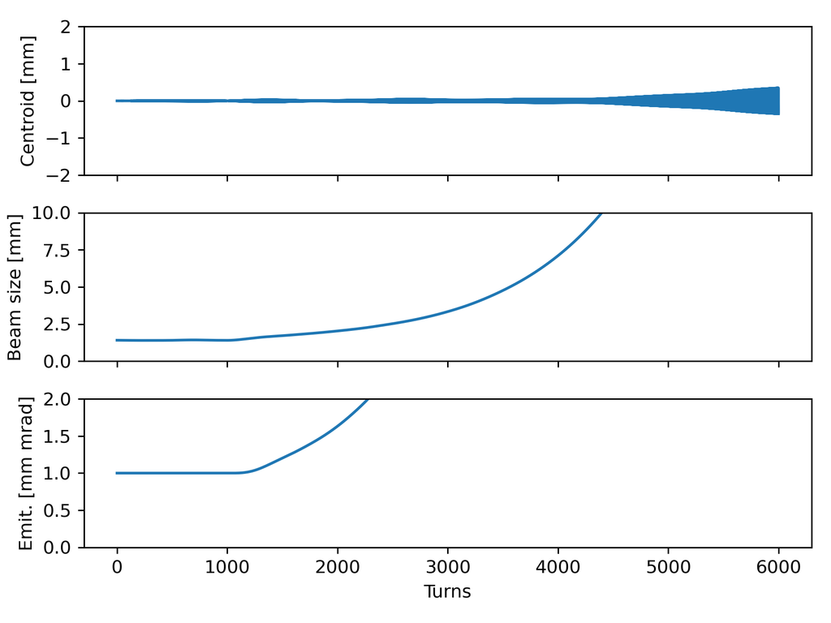

```python
from map2D import map2D
import numpy as np
import matplotlib.pyplot as plt
#from matplotlib import animation
#from IPython.display import HTML
%matplotlib notebook

quad_error=map2D(npart=10000, twiss=[2,1], twiss_beam=[2,1],tune=0.5005, chrom=5.0, espr=1.0e-4)
avex,avep,sizex,sizep,emit=quad_error.statistics()
emitlist=[]
sizelist=[]
avelist=[]
N_turn=6000


def evolve_func(turns, kick_turn_start=1000, df=1.0e-3,
               ):
    for i in range(turns):
        if i>=kick_turn_start:
            quad_error.coor2D[1,:]+=df*quad_error.coor2D[0,:]



        quad_error.propagate()

        avex,avep,sizex,sizep,emit=quad_error.statistics()
        avelist.append(avex)
        sizelist.append(sizex)
        emitlist.append(emit)
        yield quad_error.coor2D

evolve=evolve_func(N_turn+2)

for i in range(N_turn):
    arr=next(evolve)

fig1,(ax1,ax2,ax3)=plt.subplots(3,1, sharex= True)
ax3.set_xlabel("Turns")
ax1.set_ylabel("Centroid [mm]")
ax2.set_ylabel("Beam size [mm]")
ax3.set_ylabel("Emit. [mm mrad]")
ax1.plot(np.array(avelist)*1e3)
ax1.set_ylim([-2,2])
ax2.plot(np.array(sizelist)*1e3)

ax2.set_ylim([0,10])
ax3.set_ylim([0,2])
ax3.plot(np.array(emitlist)*1e6)
fig1.tight_layout()
```